# COVID-19 Data Analyzation and Prediction

## Investigation Overview

> With 168,019 confirmed cases and 6,610 deaths, 148 countries were affected (*by March 16th*) by the Coronavirus disease. This outbreak has gone way beyond what we expected. This pandemic caused WHO (World Health Organization) to raise the health emergency to its highest level along with many more countries' top emergency warnings. This project is targeted to briefly analyze the COVID-19 outbreak in the United States with some comparison against China (worst hit area) along with a rough prediction of the spreading trend.

## Dataset Overview

> Data set is operated by the Johns Hopkins University Center for Systems Science and Engineering (JHU CSSE). Also, Supported by ESRI Living Atlas Team and the Johns Hopkins University Applied Physics Lab (JHU APL). I extracted 2900 records cover information for two countries, 1682 records in China and 1218 records in the U.S.. Information is recorded from 2020 Jan 22nd until 2020 Mar 15th.

```python
## import all packages and set plots to be embedded inline
import numpy as np
import pandas as pd
import matplotlib.pyplot as plt
import seaborn as sns
import glob
%matplotlib inline
from scipy.optimize import curve_fit
import urllib
import time

pd.options.mode.chained_assignment = None  # default='warn'

# suppress warnings from final output
import warnings
warnings.simplefilter("ignore")
```

```python
# load in the dataset into a pandas dataframe
df= pd.read_csv('csse_covid_19_data/df.csv')
# change datetime dtype
df['Last_Update']= df['Last_Update'].astype('datetime64')
## break data by contries for future analyzation
usdf = df.query('Country_Region == "US"')
cndf = df.query('Country_Region == "China"')
```

## Confirmed cases geographic distribution

> Given the fact that the following plot is based on frequencies of geographical values show up in the data set, we don’t expect any correlation or normal distribution show up in the plot but only to reflect the way COVID-19 spread out from the geographical perspective. The plot shows the virus on record is between (-160, -65) in longitude and (20,65) in latitude. In relate, Lat-long coorditates for cities in United States are in range: Latitude from 19.50139 to 64.85694 and longitude from -161.75583 to -68.01197. This match up with what we have in the plot.

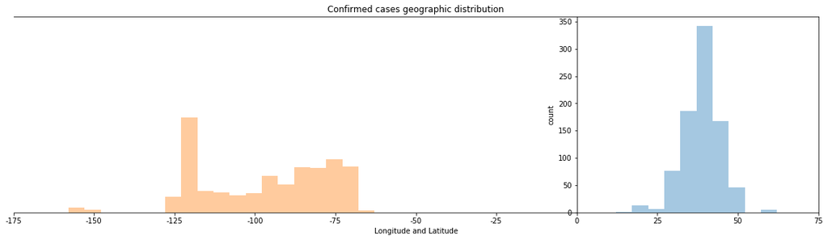

```python
## set bin edge
bin_edge = np.arange(usdf['Longitude'].min(),usdf['Latitude'].max()+5,5)
## plot
plt.figure(figsize =(20,5))
## set y axis to x= 0
plt.axes().spines['left'].set_position(('data',0))
sns.distplot(usdf['Latitude'],bins =bin_edge,kde =False)
sns.distplot(usdf['Longitude'], bins =bin_edge, kde= False)
## set xticks
tick = np.arange(-175,100, 25)
plt.xticks(tick,tick)
## set labels
plt.xlabel('Longitude and Latitude')
plt.ylabel('count')
plt.title('Confirmed cases geographic distribution');
```

## Accumulated numbers among states (up till Mar 15th)

> Following bar chart agrees with the hypothesis: Northern east and Northern west states have the most cases reported. Top four significant states are WA, NY, CA and MA.

```python
## mask
mask = usdf.query('Last_Update == "03-15-2020"')

## set up iterables
deathcols = ['Deaths','fatality_rate']
recovercols= ['Recovered','recovery_rate']
plotpos =[121,122]
def statenum(colums):
    plt.figure(figsize=(20,10))
    ## sort values descending
    if colums =='Confirmed':
        statedesc = mask.groupby('Province_State')[colums].sum().sort_values(ascending= False)
        sns.barplot(data=mask, x= statedesc.values,y = statedesc.index, color ='c')
        plt.xlabel(colums)
        plt.title('Total confirmed cases each state')
    ## limit result returned by 10 with small recoreds size
    else:
        for colum, plotpo in zip(colums,plotpos):
            plt.subplot(plotpo)
            i = mask.groupby('Province_State')[colum].sum().sort_values(ascending= False)[:12]
            sns.barplot(data=mask, y= i.values,x = i.index, color ='c')
            plt.xticks(rotation =15)
            plt.ylabel(colum)
            plt.title('Top 12 {} states'.format(colum))
```

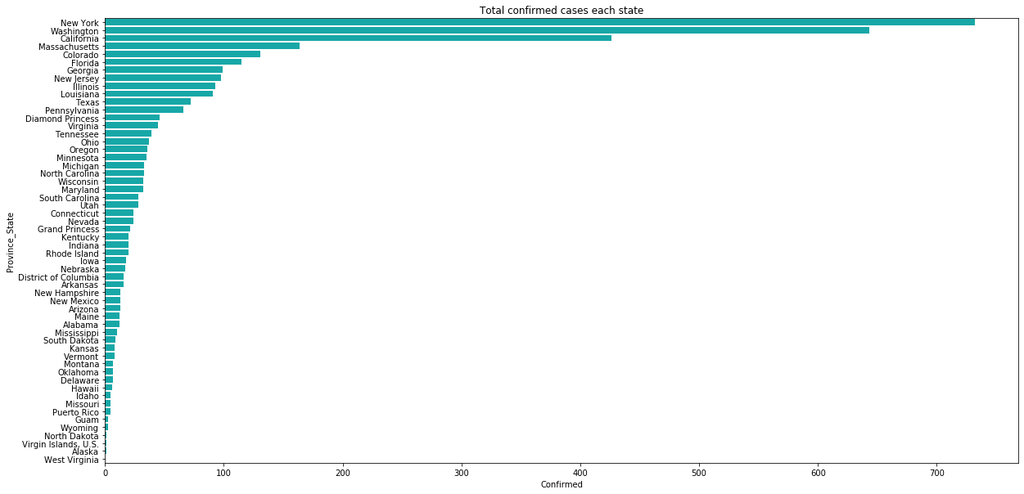

```python
statenum('Confirmed')
```

## Top 12 total deaths states VS Top 12 fatality rate states

> Total deaths show different results than fatality rate.

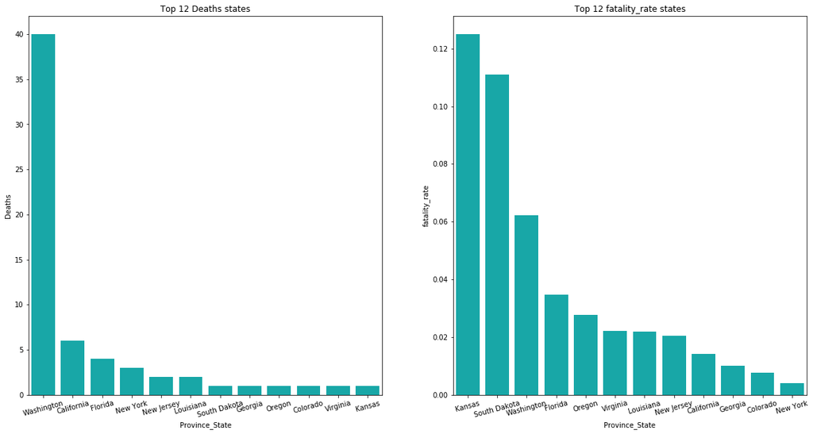

```python
statenum(deathcols)
```

## Top 12 total recoverys states VS Top 12 recovery rate states

> The total deaths/state and fatality rate/state as well as total recoveries/state and recovery rate/state are paired based on the same group of data but showing different results. They also suggest slightly different messages, using ratios might be a better way to compare event/person by state.

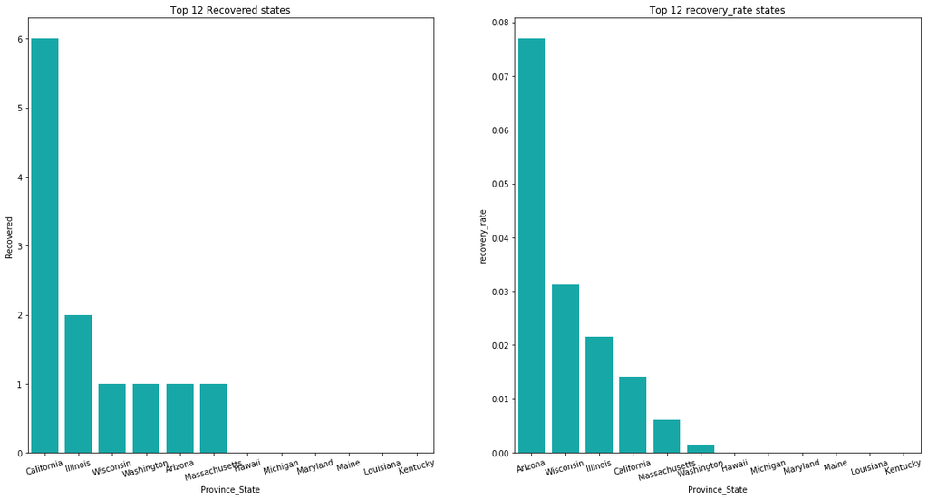

```python
statenum(recovercols)
```

## Accumulate confirmed cases along with time in China and U.S.

> Here we have a plot showing accumulate confirmed cases along with time between China and U.S.. There is a worrisome trend, from Jan 22nd the first COVID-19 case was observed in the U.S. it has been slowly spreading out unilt Fed 22nd a big population was infected and it started to spread out fast, giving the same frame of time the virus is spreading faster in the U.S. than in China at this moment.

```python
## aggregate by conuntries then create multi index series
countrydf = df.groupby(['Country_Region','Last_Update'])[['Confirmed','Deaths','Recovered']].sum()
## reset index
countrydf = countrydf.reset_index()
## function for compute logarithm and antilogarithm
def logtrans(x, inverse= False):
    if not inverse:
        return np.log10(x)
    else:
        return 10 ** x
```

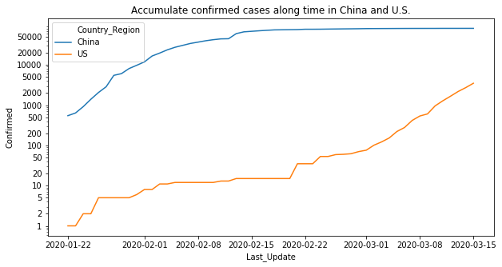

```python
## transform y scale to log10 in order
## to counter big population difference
plt.figure(figsize=(10,5))
plt.yscale('log')
sns.lineplot(data=countrydf, x ='Last_Update', y = 'Confirmed',hue= 'Country_Region' )
tick = [1,2,5,10,20,50,100,200,500,1000,2000,5000,10000,20000,50000]
plt.yticks(tick,tick)
plt.legend(loc =0)
plt.title('Accumulate confirmed cases along time in China and U.S.');
```

## Total Recovered and total Deaths between two countries

> Scatter plot show a relationship between total Recovered and total Deaths within two countries. This make sense because more recovered reflect more cases confirmed which will lead to more deaths. What we want to see is a steep slop along those spots, the steeper slop is the more people recovered than died. In this case, China shows a more comforting result.

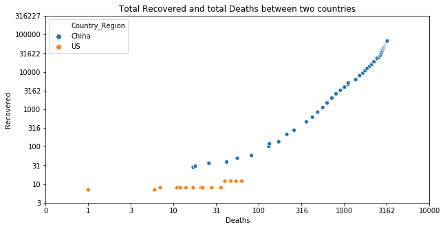

```python
plt.figure(figsize=(10,5))
## perform log transformation
sns.scatterplot(data= countrydf,y= countrydf['Recovered'].apply(logtrans),
                x =countrydf['Deaths'].apply(logtrans), hue= 'Country_Region')
## get x,t ticks locations and labels
xlocs, xlabels= plt.xticks()
ylocs, ylabels= plt.yticks()
## transform labels
xlabels = logtrans(xlocs, inverse= True).astype(int)
ylabels = logtrans(ylocs, inverse= True).astype(int)
plt.xticks(xlocs, xlabels)
plt.yticks(ylocs, ylabels)
plt.legend(loc= 0)
plt.title('Total Recovered and total Deaths between two countries');
```

## Average ratio comparisons

> Following plots compare average recovery rate as well as average fatality rate between two contries. Fortunately both counrties showing a higher average recovery rate than average fatality rate. Red dots represent rates on Mar 15th respectively.

```python
## Add fatality rate and recovery rate
countrydf['fatality_rate'] = countrydf['Deaths']/countrydf['Confirmed']
countrydf['recovery_rate'] = countrydf['Recovered']/countrydf['Confirmed']
uptodate = countrydf.query('Last_Update=="2020-03-15"')
```

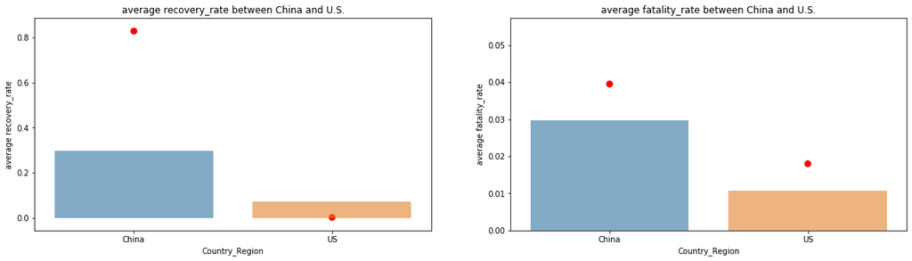

```python
indexes = [121, 122]
columnames =['recovery_rate','fatality_rate']
plt.figure(figsize=(20,5))
for index, columname in zip(indexes,columnames):
    plt.subplot(index)
    ## use red dot to indicate most recent rates
    sns.pointplot(data = uptodate, x = 'Country_Region', y= columname,color ='r',join =False,edgecolors="white")
    sns.barplot(data= countrydf, x= 'Country_Region', y= columname, ci= False, alpha = 0.6)
    plt.ylabel('average {}'.format(columname))
    plt.title('average {} between China and U.S.'.format(columname));
```

## Prediction

> Following is a prediction model using logistic growth algorithm. In the title, max infections represent predicted maximum total confirmed cases within 30 days; r is the per capita rate of increase. The greater r is, the faster the rise to the peak. As the model shows, max confirmed cases would likely be around 13,716 winthin 30 days, which will happen around second week in April.

```python
dummydf = countrydf.query('Country_Region=="US"')
## function for obtain dates from Jan 22nd
def get_date_list(target_month = 3):
    month_day = [0, 31, 29, 31, 30, 31, 30, 31, 31, 30, 31, 30, 31]
    cur_month, cur_day = 1, 22
    ans = []
    while cur_month <= target_month:
        while cur_day <= month_day[cur_month]:
            d = "0" + str(cur_day) if cur_day < 10 else str(cur_day)
            ans += [str(cur_month) + "/" + d]
            cur_day += 1
        cur_day = 1
        cur_month += 1
    return ans
## logistic function model
def logistic_function(t, K, P0, r):
    t0 = 0
    exp = np.exp(r * (t - t0))
    return (K * exp * P0) / (K + (exp - 1) * P0)
## main function body
def predict(dayframe):
    ## how many days to predicte from today
    ## aka dayframe
    predict_days = dayframe

    date, confirm = dummydf['Last_Update'].values, dummydf['Confirmed'].values
    x = np.arange(len(confirm))
    date_labels = get_date_list(4)

    ## convert least sqrt
    popt, pcov = curve_fit(logistic_function, x, confirm, maxfev=9000)
    #print(popt)

    predict_x = list(x) + [x[-1] + i for i in range(1, 1 + predict_days)]
    predict_x = np.array(predict_x)
    predict_y = logistic_function(predict_x, popt[0], popt[1], popt[2])

    ## plot
    plt.figure(figsize=(20, 10))
    plt.plot(predict_x, predict_y, 's',label="predicted infected number",alpha= 0.6)
    plt.plot(x, confirm, 'o',label="confimed infected number")
    plt.xticks(predict_x, date_labels[:len(predict_x) + 1], rotation=90)

    plt.suptitle("U.S. region COVID-19 infected numbers prediction (30 days frame. Max infections: {},  r:{:.3})".format(int(popt[0]),
                                                                                popt[2]), fontsize=16, fontweight="bold")
    plt.title("Predict time:{}".format(time.strftime("%Y-%m-%d", time.localtime())), fontsize=16)
    plt.xlabel('date', fontsize=14)
    plt.ylabel('infected number', fontsize=14)
    plt.legend(loc= 0)
```

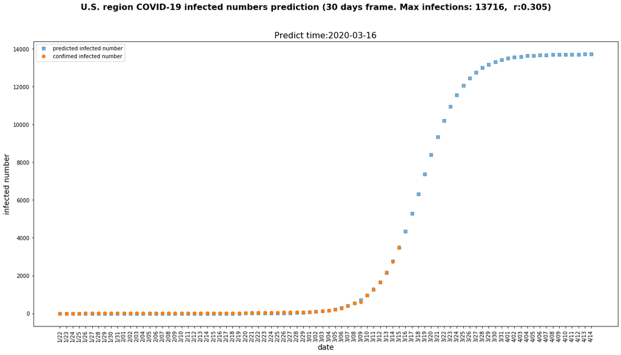

```python
## call function using 30 dayframe
predict(30)
```

> Limitation: This model has very limited perspective, since the dataset is not large enough to train the model at this point (represented by orange dots). The model does not yet take other elements into consideration, eg SEIR model, SIRS model, susceptible and infective mobility, medical break though and many more.

**This project is out of personal interest and it is for demonstration only, it should not be used for academical research nor clinical purpose.**

> Once you're ready to finish your presentation, check your output by using nbconvert to export the notebook and set up a server for the slides. From the terminal or command line, use the following expression:

> > `jupyter nbconvert 'COVID_19 data analyzation and prediction presentation.ipynb' --to slides --post serve --template output_toggle`

> This should open a tab in your web browser where you can scroll through your presentation. Sub-slides can be accessed by pressing 'down' when viewing its parent slide. Make sure you remove all of the quote-formatted guide notes like this one before you finish your presentation!